# Linear regression [session notes]

Author

Denis Schluppeck

## Introduction

Some details about fitting line through data points as a canonical example, but also relationship to other more complex examples that can be cast as linear regression problems. MvR referred to *Numerical Recipes* for really good theoretical background, but also practical advice Press et al. (1992). You can [try here](https://www.aquila.infn.it/pierleoni/LFC/ROUTINES/Chap15.pdf) or google for a PDF copy of the relevant chapter 15.0 on *Modelling data*) :

Press, William H., Saul A. Teukolsky, William T. Vetterling, and Brian P. Flannery. 1992. *Numerical Recipes in c*. Second. Cambridge, USA: Cambridge University Press.

- fitting polynomials is also linear problem
- reality check: any function that’s linear in parameters is also ok, eg. $y(t; a, b, c) = a\cdot e^{-t} + b\cdot x + c$

## Basic ideas

- Derivation from a Bayesian point of view, assuming a flat prior to yield the maximum likelihood solution.

*Bayes* formulation with data $\mathcal{D}$ and parameters $w$ :

$$p(w | \mathcal{D}) = \frac{p(\mathcal{D} | w )p(w)}{p(\mathcal{D})}$$

but in the case of a flat prior on the parameters, $p(w)$, and given that $p(\mathcal{D})$ is just a normalising constant, we can find the maximum of $p(w | \mathcal{D})$, by maximising $p(\mathcal{D} | w )$, also known as the likelihood.

For *iid* Gaussian noise, the likelihood becomes

$$\mathcal{L} = \prod_i \Big\{ \exp{\Big[-\frac{1}{2}\Big(\frac{y_i -y(x_i)}{\sigma} \Big)^2} \Big] \Delta y\Big\}$$

and maximising the likelihood is equivalent to minimising the negative log of the likelihood (numerically better behaved)
$$-\log \mathcal{L} = \sum_i \frac{\Big(y_i -y(x_i)\Big)^2}{2\sigma^2} -N \log \Delta y$$

## Relationship to $\chi^2$ fitting

If the errors vary with each measurement point (rather than being of a fixed, single $\sigma$), then these errors can be included in the quantity to be minimised and leads to the $\chi^2$ statistic

$$\chi^2 = \sum_i \Big( \frac{y_i-y(x_i; a_1\dots, a_M )}{\sigma_i} \Big)^2$$

where $(x_i, y_i)$ are data points with an associated error $(\sigma_i)$. For the Gaussian case, s $\chi^2$ value of a moderately good fit is on the order of the degrees of freedom $\nu = N-M$ (number of measurement points minus number of parameters).

## Linear algebra picture

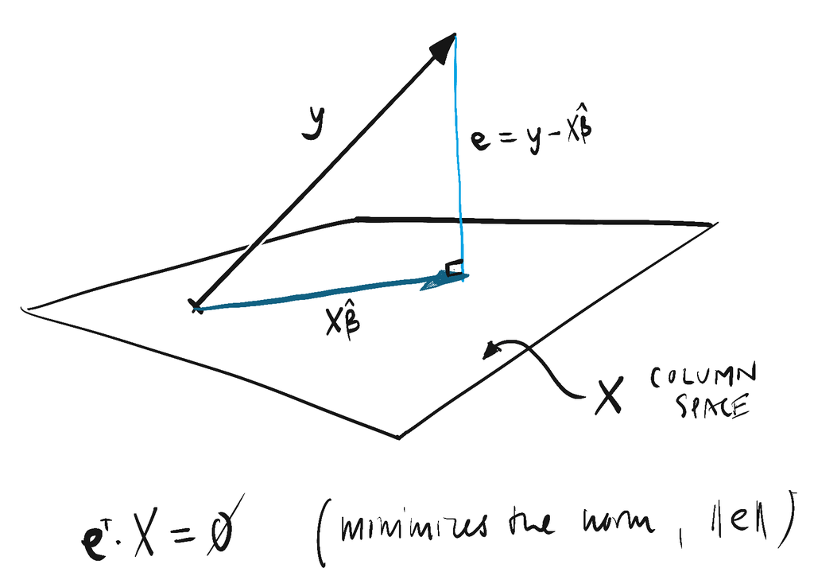

drawing of the linear algebra picture of regression

## Ideas

Consider the data $\mathbf{y}$ as a vector in some space and $\mathbf{X}$, the design matrix with an associated column space.

$\mathbf{y}$ is usually not in the column space of $\mathbf{X}$ (eg. a set of many $y_i$ values measured at $x_i$ are unlikely to fall onto a line, which is parameterised by two values).

But we can find an $\mathbf{X}\mathbf{\hat{\beta}}$, such that the distance to the data $\mathbf{y}$ is smallest. This error $\mathbf{e}$ is orthogonal to the space defined by $\mathbf{X}$, so the dot products of $\mathbf{e}$ which each columns in $\mathbf{X}$ must be $0$.

This leads to:
$$\begin{eqnarray}
\mathbf{e}^T\mathbf{X} &=& 0 \\
(\mathbf{y} - \mathbf{X}\mathbf{\hat{\beta}})^T\mathbf{X} &=& 0 \\
\mathbf{X}^T(\mathbf{y} - \mathbf{X}\mathbf{\hat{\beta}}) &=& 0 \\
\mathbf{X}^T\mathbf{X}\mathbf{\hat{\beta}} &=& \mathbf{X}^T\mathbf{y} \\
\mathbf{\hat{\beta}} &=& (\mathbf{X}^T\mathbf{X})^{-1}\mathbf{X}^T\mathbf{y} \\
\end{eqnarray}$$

See also “The Linear Algebra Behind Linear Regression” (2020) and Geer (2019)

“The Linear Algebra Behind Linear Regression.” 2020. *GoDataDriven*. https://godatadriven.com/blog/the-linear-algebra-behind-linear-regression/.

Geer, Ruben van de. 2019. “A Primer (or Refresher) on Linear Algebra for Data Science.” *YouTube*. https://www.youtube.com/watch?v=Qz58vTa8-SY.